# Study on the Birth Rate in the U.S.A.

SATST531 Midterm Project

Yurui Chang, Haichao Ji, Ruoyang Liu

# 1.Introduction

Growth of population has always been a concern for governments of many countries. The birth rate is one of the most significant indicators that influence the population and structure of the population. It determines the speed of growth of population and the percentage of people of different ages in a country. It is well known that the scale and structure of population have important effects on the development of economics, education and social structure. Also, the birth rate depends on various factors, such as economics, and agricultural production, science and technology, especially medical level, and culture. Exploring the features of birth through history can help us view the development and constantly changing culture of a country.

The United States, the fastest developed country in the 20th century, its birth may let us view a tip of the iceberg that why the USA can develop so fast in the last century that it must have certain relation with economics, science and culture. Therefore, we would like to select birth data of the late-20-century of the United States as a research object and make a time series analysis to find out the regulation and trend of the birth.

The data we selected is CDC Births Data 1969-2008 [1]. This data is drawn from the USA Centers for Disease Control and Prevention. There are 5 columns which include 4 numerical variables and 1 categorical variable. The numerical variables are year, month, day and birth. The categorical variable is gender(Male and Female). We selected the data from 1969 to 1988 as we would like to explore the birth before the important timeline–the collapse of the Soviet Union as it is a turning point which has enormous influence on every part of the US. We will use the data to make a time series analysis of the monthly birth of the US.

In this report, we will use $\text{SARIMA}$ method to explore the birth through time series. The report will be divided into parts. The first one is data exploration which includes the overall view of data, heteroscedasticity and decomposition of data. We also determine stationary in this part. The second section is model selection. We use Grid Search method to obtain the best fitted model. The third section is to test the model. We will carry out diagnostics in this part. The last section is the conclusion and possible improvement.

# 2.Data Exploration

The information we used includes dates and birth rate. Firstly, we make a plot of birth for every month with the original data. We intend to find out the relation of birth rate and the changes of birth between different months. Thus, we make the month variable from 1969 to 1988 to be a consecutive variable. As it can be seen from the time series plot with birth as y-label and month as x-label, the trend of the data can be approximately splitted into 3 parts. The first is approximately from 0 to 25, which has a significant increasing trend. The second part is from 25 to 50, and the values are descending. The last part, generally, shows an evident increasing trend. Besides the trend of the time series data, we also notice that the data has very regular fluctuations which seem to have periodicity. We, therefore, suppose that this data may fit with a $\text{SARIMA}$ model with overall trend and periodic seasoning effect. Before the subsequent process of analysis and model selection, the original data is found to be heteroscedastic and non-stationary. Hence, we transform the data through logarithm and then difference it. Thereafter, our data successfully meets the model assumption and is stationary. We further use grid search method to determine other parameters as long as we figure out the periodicity by using the logged data. More details have been presented in the following.

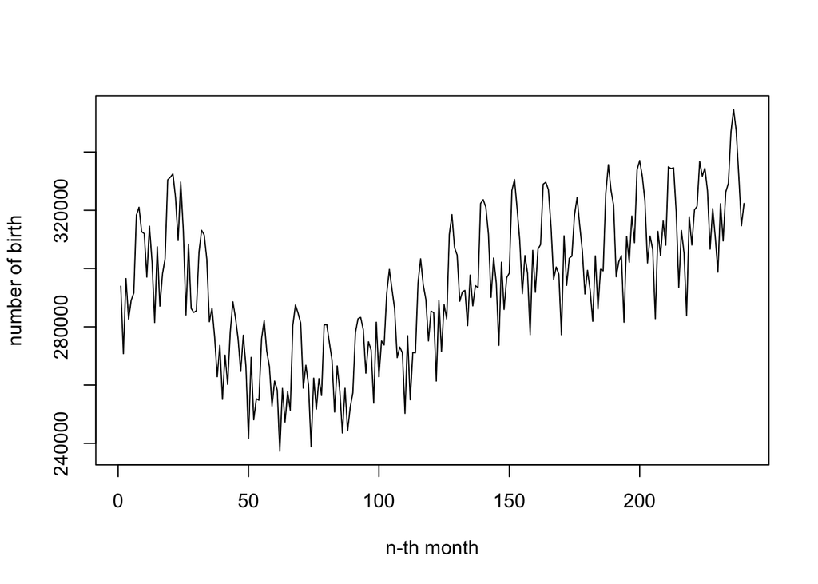

## 2.1 Heteroscedasticity Removing

The series shows compound growth and has evident patterns, which is a sign of heteroscedasticity, and the logarithm may be helpful to remove the increase in variance. Taking the logarithm of the data will not fatten an inflationary growth pattern, but it will straighten it out so that it can be fitted by a linear model(e.g., a random walk or ARIMA model with constant growth, or a linear exponential smoothing model) [2]. Also, taking the logarithm of the data will convert multiplicative seasonal patterns to additive patterns, so that if we perform seasonal adjustments after taking the logarithm, we should use the additive type.

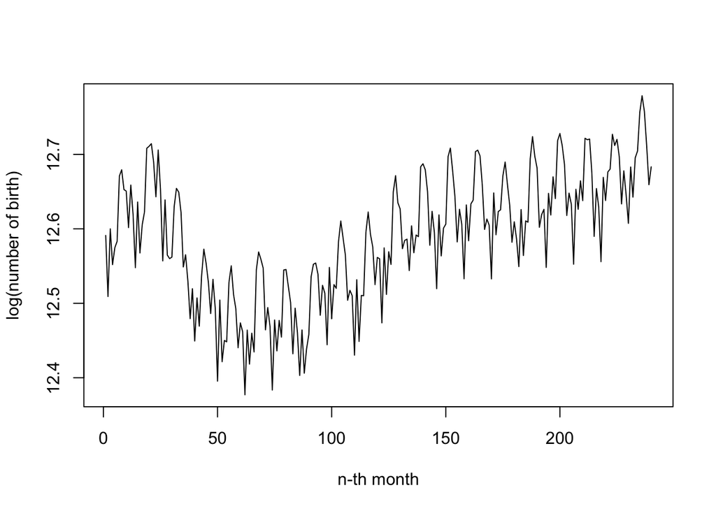

Log serves our purpose since it did remove the increase in variance.

## 2.2 Data Decomposition

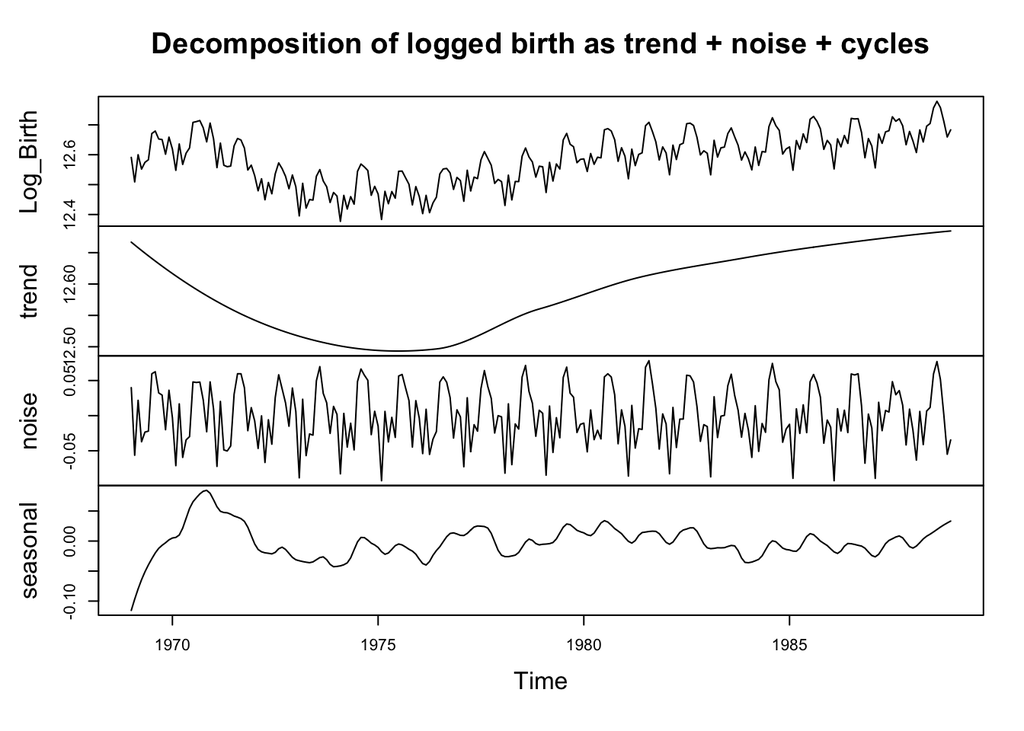

Based on the decomposition of the time series[3], we could figure out that this birth series is generally a combination of level, trend, seasonality, and noise components.

## 2.3 Stationarity Check

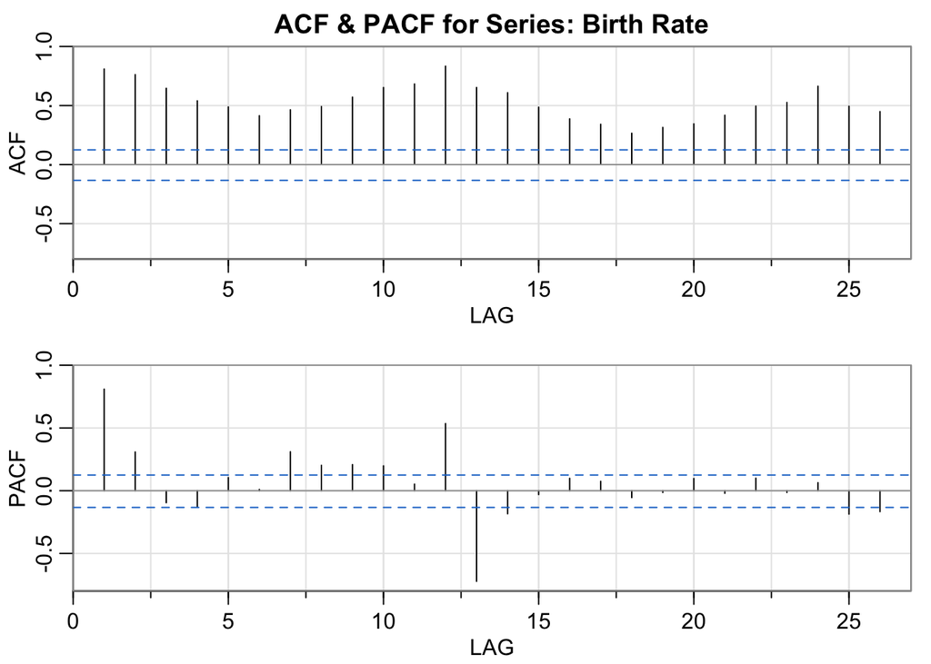

```
##      [,1] [,2]  [,3]  [,4] [,5] [,6] [,7] [,8] [,9] [,10] [,11] [,12] [,13]
## ACF  0.81 0.76  0.65  0.54 0.49 0.41 0.46 0.49 0.57  0.65  0.68  0.83  0.65
## PACF 0.81 0.31 -0.10 -0.13 0.10 0.01 0.31 0.20 0.21  0.20  0.05  0.54 -0.72
##      [,14] [,15] [,16] [,17] [,18] [,19] [,20] [,21] [,22] [,23] [,24] [,25]
## ACF   0.61  0.49  0.39  0.34  0.27  0.31  0.34  0.42   0.5  0.53  0.66  0.49
## PACF -0.18 -0.03  0.10  0.07 -0.05 -0.01  0.10 -0.02   0.1 -0.01  0.06 -0.19
##      [,26]
## ACF   0.45
## PACF -0.17
```

We have seen by the ACF and PACF that this is not white noise, but a series of correlated values. Nevertheless, we can do the Augmented Dickey-Fuller (ADF) t-test on the time series to formally validate this claim.

```
##
##  Augmented Dickey-Fuller Test
##
## data:  birth_per_month
## Dickey-Fuller = -3.0785, Lag order = 6, p-value = 0.1223
## alternative hypothesis: stationary
```

By using adf.test, it yields a big p-value which shows the data is not stationary. So this supports our ACF plot consideration above where we stated: it is likely that this is not purely white noise and some time series information exists in this data. Actually, there is an obvious trend in the time series, and thus we difference the data to detrend it. The corresponding figure is shown below and proves that the series now does not have apparent trend now:

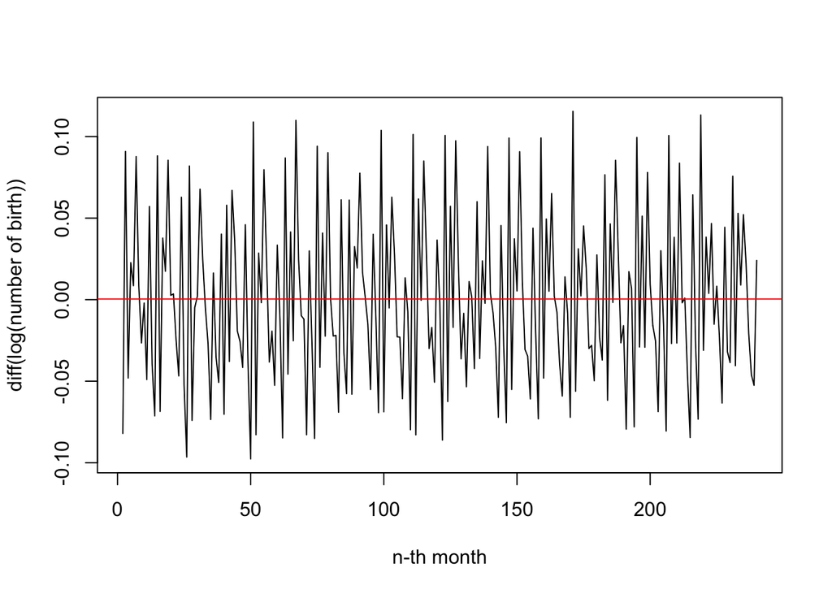

## 2.4 Period Detection

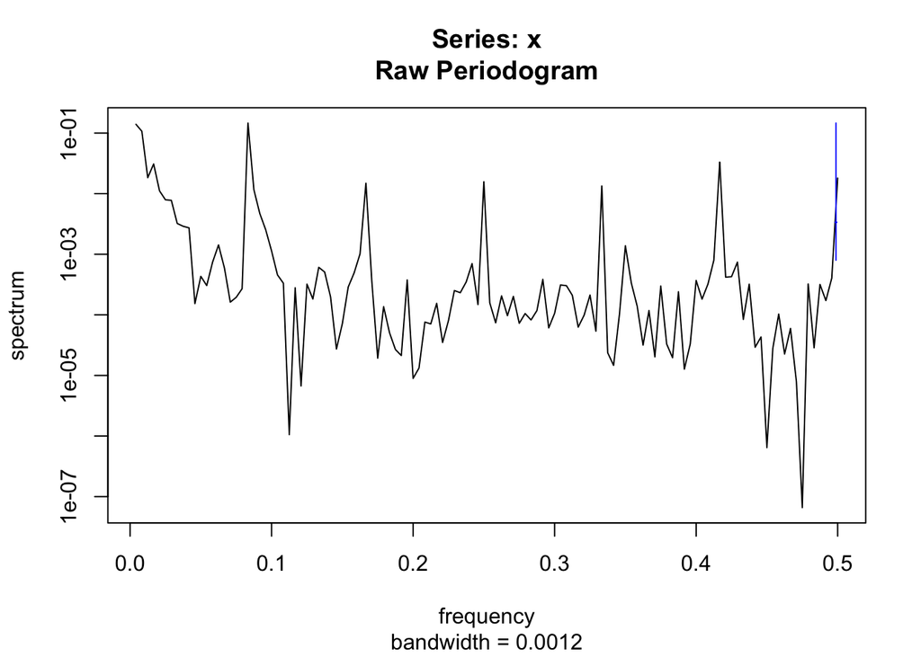

# 3. Model Selection

## 3.1 SARIMA Model

Given the period equals to 12 (one year). It is supposed to conduct a general $\text{SARIMA}(p,1,q)\times(P,1,Q)_{12}$ model [4] for monthly data:

$$\phi(B)\Phi(B^{12})(Y_n - \mu) = \psi(B)\Psi(B^{12})\epsilon_n$$

## 3.2 Hyperparameters Configuration by Grid Search

Plot the ACF and PACF of monthly births number with first `diff` 1 and then `diff` with a period:

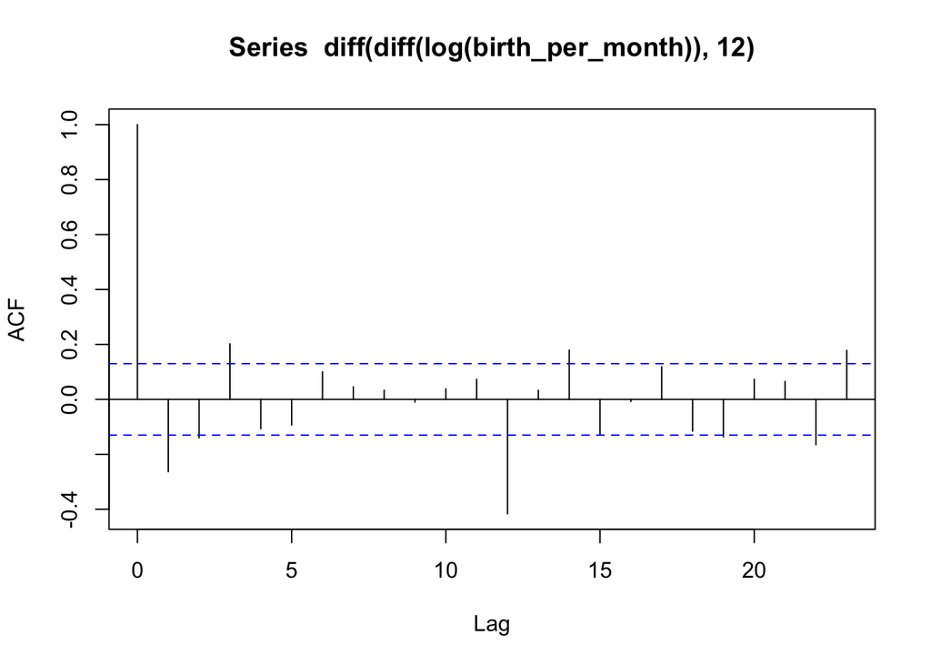

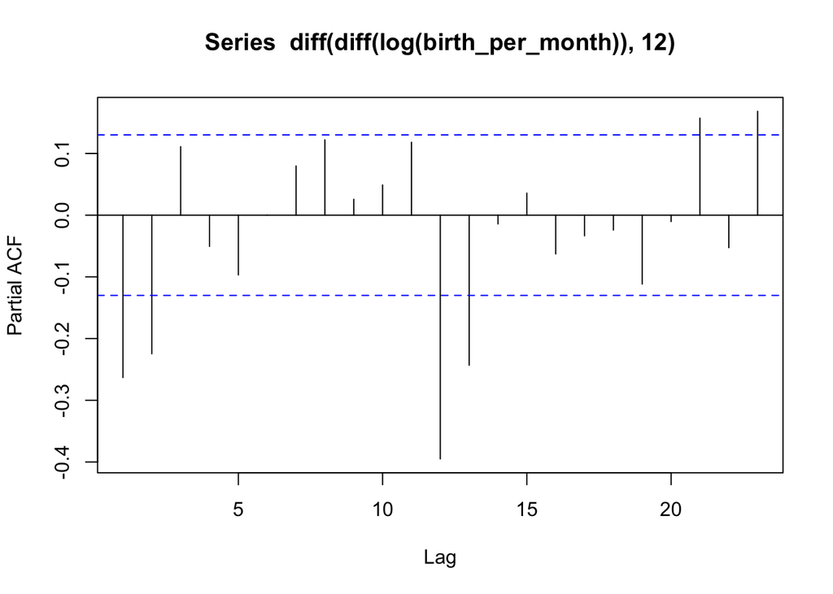

According to ACF and PACF, $P,Q,p,q$ can be roughly estimated as $p = 1,2$, $q = 0, 1, 2, 3$, $P = 0,1$, and $Q = 0,1$. Some possible models will be conducted and compared with AIC. We try to find the optimal model by grid search method[5], and the results are listed here:

For $P = Q = 0$:

|  | MA0 | MA1 | MA2 | MA3 |
| --- | --- | --- | --- | --- |
| AR0 | -1111.794 | -1132.221 | -1131.090 | -1132.855 |
| AR1 | -1126.100 | -1130.637 | -1139.385 | -1132.554 |
| AR2 | -1135.789 | -1136.430 | -1140.423 | -1144.844 |

For $P = 1, Q = 0$:

|  | MA0 | MA1 | MA2 | MA3 |
| --- | --- | --- | --- | --- |
| AR0 | -1155.080 | -1183.848 | -1182.144 | -1182.904 |
| AR1 | -1178.725 | -1181.998 | -1181.566 | -1183.456 |
| AR2 | -1186.145 | -1187.261 | -1186.935 | -1184.682 |

For $P = Q = 1$:

|  | MA0 | MA1 | MA2 | MA3 |
| --- | --- | --- | --- | --- |
| AR0 | -1206.814 | -1225.003 | -1223.068 | -1224.053 |
| AR1 | -1222.010 | -1223.032 | -1221.616 | -1224.838 |
| AR2 | -1226.068 | -1227.809 | -1228.345 | -1249.984 |

The model with smallest AIC is chosen to be the final model, which is $\text{SARMA}(2,1,3)\times(1,1,1)_{12}$.

|  | Dependent variable |  |  |
| --- | --- | --- | --- |
| Predictors | Estimates | CI | p |
| ar1 | -1.16 | -1.17 – -1.15 | **<0.001** |
| ar2 | -1.00 | -1.00 – -1.00 | **<0.001** |
| ma1 | 0.93 | 0.79 – 1.06 | **<0.001** |
| ma2 | 0.75 | 0.58 – 0.91 | **<0.001** |
| ma3 | -0.22 | -0.35 – -0.08 | **0.001** |
| sar1 | -0.13 | -0.30 – 0.03 | 0.118 |
| sma1 | -0.72 | -0.84 – -0.59 | **<0.001** |
| Observations | 227 |  |  |
| R<sup>2</sup> | 0.973 |  |  |

The final established model is
$$Y_n = -1.1593Y_{n-1} - 0.9994Y_{n-2} - 0.1283Y_{n-12} +\epsilon_n + 0.9269\epsilon_{n-1} + 0.7489\epsilon_{n-2} - 0.219\epsilon_{n-3} - 0.7169\epsilon_{n-12}$$

where $Y_n$ is the logarithm of birth number in n-th month,$\{\epsilon\}$ is a white noise process with variance $\sigma^2 = 0.0002047$.